# **Merge Sort**

Merge Sort merupakan algoritma pengurutan dengan konsep rekursif, yang terdiri dari dua tahapan utama, yaitu

1. *Splitting atau proses divide*
2. *Merging*

## **Divide**

Proses Splitting atau Divide adalah proses yang membagi list data menjadi dua buah bagian. Proses splitting data list ini dilakukan secara terus menerus, sampai hanya tersisa satu elemen saja didalam list. Top-Down Process  
Contoh proses ini dapat dilihat pada Gambar 1 berikut :

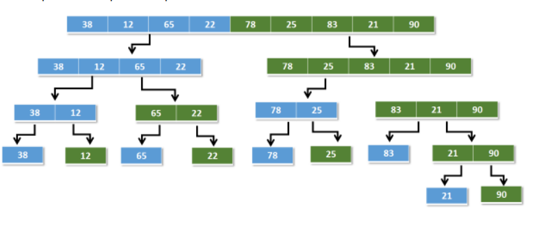

**Gambar 1. Proses Divide pada Merge Sort**

Pada Gambar 1 tersebut ditunjukkan bahwa data yang terdiri dari sembilan elemen, yaitu [38, 12, 65, 22, 78, 25, 83, 21, 90]. Pada proses divide ini, data dibagi menjadi dua bagian kiri (warna biru) dan kanan (warna hijau), sehingga data bagian kiri terdiri dari empat elemen, yaitu [38, 12, 65, 22], sedangkan bagian kanan menjadi [78, 25, 83, 21, 90]. Proses ini dilakukan terus menerus, sehingga terdapat data yang hanya memiliki satu elemen saja, yaitu [38], [12], [65], [22], [78], [25], [83], [21], dan [90].

Kembali ke Menu Awal

## **Merge**

Proses Merge ini menggabungkan data-data yang sudah terbagi pada Tahap pertama (divide/split). Proses merge ini juga melibatkan proses membandingkan data antara list yang akan digabung. Sehingga, setelah proses merge, data pada list akan terurut. Proses ini akan dilakukan terus menerus, sehingga tidak ada lagi list yang akan digabungkan. Tahapan merge ini adalah  
**Bottom - up process**  
Contoh proses merge dapat dilihat pada Gambar 2 berikut

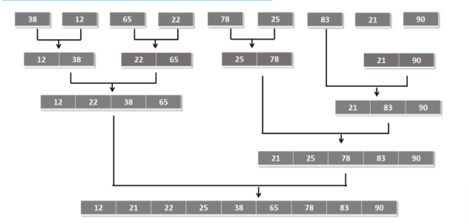

**Gambar 2. Proses Merge pada Merge Sort**

Pada Gambar tersebut ditunjukka, pada proses merging, data yang terdapat pada list yang akan digabung, dibandingkan terlebih dahulu, jika data lebih kecil, maka data tersebut akan diletakkan pada indeks yang lebih rendah, sehingga setelah proses merging selesai, data sudah dalam keadaan terurut.

### Code

Berikut adalah code untuk algoritma pengurutan Merge Sort, dan contoh pemanggilan fungsi merge sort ini.

```python
def merge_sort(a_list):
    print("Splitting ",a_list)
    if len(a_list) > 1:
        mid = len(a_list) // 2
        left_half = a_list[:mid]
        right_half = a_list[mid:]
        merge_sort(left_half)
        merge_sort(right_half)
        i = 0 #indeks left half
        j = 0 #indeks right half
        k = 0 #indeks hasil merging/sorting
        while i < len(left_half) and j < len(right_half):
            if left_half[i] < right_half[j]:
                a_list[k] = left_half[i]
                i += 1
            else:
                a_list[k] = right_half[j]
                j += 1
            k += 1

        while i < len(left_half):
            a_list[k] = left_half[i]
            i += 1
            k += 1

        while j < len(right_half):
            a_list[k] = right_half[j]
            j += 1
            k += 1

    print("Merging ",a_list)
```

```python
a = [38,12,65,22,78,25,83,21,90]
merge_sort(a)
```

```
Splitting  [38, 12, 65, 22, 78, 25, 83, 21, 90]
Splitting  [38, 12, 65, 22]
Splitting  [38, 12]
Splitting  [38]
Merging  [38]
Splitting  [12]
Merging  [12]
Merging  [12, 38]
Splitting  [65, 22]
Splitting  [65]
Merging  [65]
Splitting  [22]
Merging  [22]
Merging  [22, 65]
Merging  [12, 22, 38, 65]
Splitting  [78, 25, 83, 21, 90]
Splitting  [78, 25]
Splitting  [78]
Merging  [78]
Splitting  [25]
Merging  [25]
Merging  [25, 78]
Splitting  [83, 21, 90]
Splitting  [83]
Merging  [83]
Splitting  [21, 90]
Splitting  [21]
Merging  [21]
Splitting  [90]
Merging  [90]
Merging  [21, 90]
Merging  [21, 83, 90]
Merging  [21, 25, 78, 83, 90]
Merging  [12, 21, 22, 25, 38, 65, 78, 83, 90]
```

Kembali ke Menu Awal

```python
def merge_sort(a_list):
    print("Splitting ",a_list)
    if len(a_list) > 1:
        mid = len(a_list) // 2
        left_half = a_list[:mid]
        right_half = a_list[mid:]
        merge_sort(left_half)
        merge_sort(right_half)
        i = 0 #indeks left half
        j = 0 #indeks right half
        k = 0 #indeks hasil merging/sorting
        while i < len(left_half) and j < len(right_half):
            if left_half[i] > right_half[j]:
                a_list[k] = left_half[i]
                i += 1
            else:
                a_list[k] = right_half[j]
                j += 1
            k += 1

        while i < len(left_half):
            a_list[k] = left_half[i]
            i += 1
            k += 1

        while j < len(right_half):
            a_list[k] = right_half[j]
            j += 1
            k += 1

    print("Merging ",a_list)

a = [38,12,65,22,78,25,83,21,90]
merge_sort(a)
```

```
Splitting  [38, 12, 65, 22, 78, 25, 83, 21, 90]
Splitting  [38, 12, 65, 22]
Splitting  [38, 12]
Splitting  [38]
Merging  [38]
Splitting  [12]
Merging  [12]
Merging  [38, 12]
Splitting  [65, 22]
Splitting  [65]
Merging  [65]
Splitting  [22]
Merging  [22]
Merging  [65, 22]
Merging  [65, 38, 22, 12]
Splitting  [78, 25, 83, 21, 90]
Splitting  [78, 25]
Splitting  [78]
Merging  [78]
Splitting  [25]
Merging  [25]
Merging  [78, 25]
Splitting  [83, 21, 90]
Splitting  [83]
Merging  [83]
Splitting  [21, 90]
Splitting  [21]
Merging  [21]
Splitting  [90]
Merging  [90]
Merging  [90, 21]
Merging  [90, 83, 21]
Merging  [90, 83, 78, 25, 21]
Merging  [90, 83, 78, 65, 38, 25, 22, 21, 12]
```